# week_08_review_scatter_plots

## CMPINF 2100 Week 08

### Review Scatter Plots - Coloring by a third variable

## Import Modules

```python
import numpy as np
import pandas as pd
import matplotlib.pyplot as plt

import seaborn as sns
```

## Read data

```python
penguins = sns.load_dataset("penguins")
```

```python
penguins.info()
```

```
<class 'pandas.core.frame.DataFrame'>
RangeIndex: 344 entries, 0 to 343
Data columns (total 7 columns):
 #   Column             Non-Null Count  Dtype
---  ------             --------------  -----
 0   species            344 non-null    object
 1   island             344 non-null    object
 2   bill_length_mm     342 non-null    float64
 3   bill_depth_mm      342 non-null    float64
 4   flipper_length_mm  342 non-null    float64
 5   body_mass_g        342 non-null    float64
 6   sex                333 non-null    object
dtypes: float64(4), object(3)
memory usage: 18.9+ KB
```

## Relationships between numeric columns

We know how to create a scatterplot to visualize the relationship between 2 numeric (continuous) columns in a DataFrame.

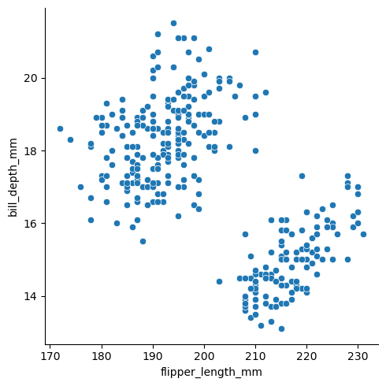

```python
sns.relplot(data=penguins, x="flipper_length_mm", y="bill_depth_mm")

plt.show()
```

### Color by a Cat or Non-Numeric column

We will include a third var in the scatterplot. The 3rd variable allows us to GROUP BY or CONDITION ON a grouping variable!!!

For example, let's color by the species variable.

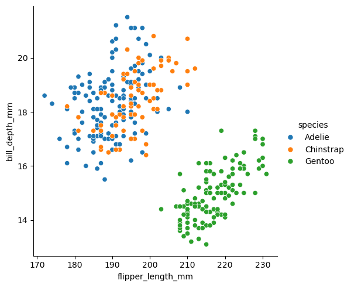

```python
sns.relplot(data=penguins, x="flipper_length_mm", y="bill_depth_mm", hue="species")

plt.show()
```

The default CAT or **QUALITATIVE** color palette is used above. We can change the palette.

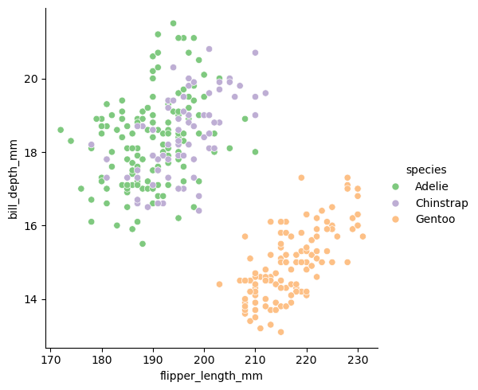

```python
sns.relplot(data=penguins, x="flipper_length_mm", y="bill_depth_mm", hue="species",
           palette="Accent")

plt.show()
```

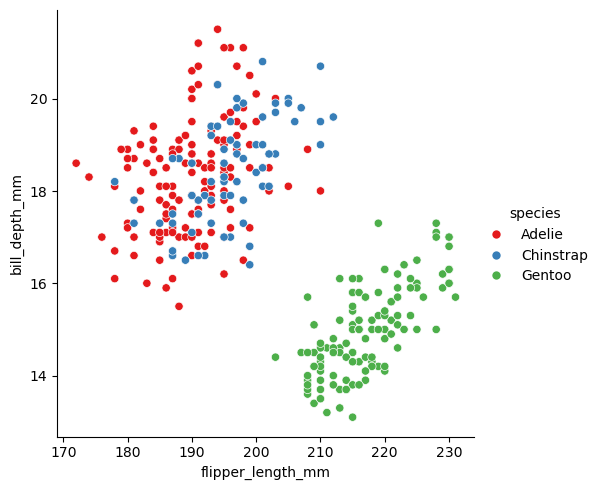

```python
sns.relplot(data=penguins, x="flipper_length_mm", y="bill_depth_mm", hue="species",
           palette="Set1")

plt.show()
```

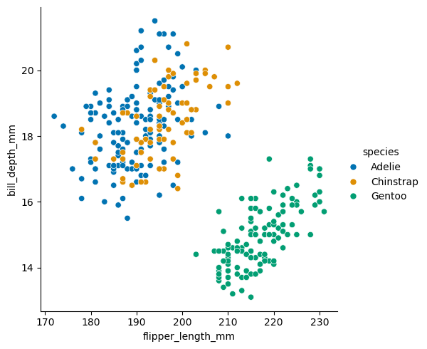

```python
sns.relplot(data=penguins, x="flipper_length_mm", y="bill_depth_mm", hue="species",
           palette="colorblind")

plt.show()
```

Most CAT or QUALITATIVE color palettes have a LIMITED num of colors to choose from.

The benefit of the default color palette is that is can handle an enormous number of categories!

### Color by NUMERIC column

We can color by a third NUMERIC or continuous variable in a scatterplot.

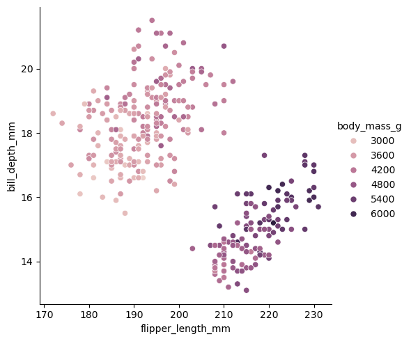

```python
sns.relplot(data=penguins, x="flipper_length_mm", y="bill_depth_mm", hue="body_mass_g")

plt.show()
```

```python
penguins.nunique()
```

```
species                3
island                 3
bill_length_mm       164
bill_depth_mm         80
flipper_length_mm     55
body_mass_g           94
sex                    2
dtype: int64
```

Key point about coloring with a numeric column is that we often times want the color palette to represent the SEQUENTIAL nature of the variable!

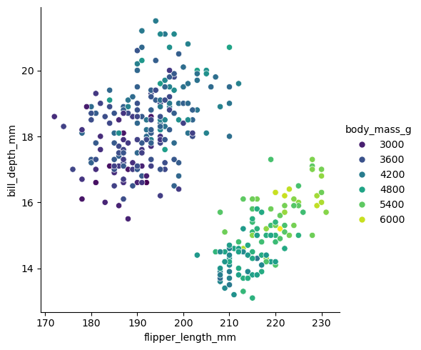

```python
sns.relplot(data=penguins, x="flipper_length_mm", y="bill_depth_mm", hue="body_mass_g",
           palette="viridis")

plt.show()
```

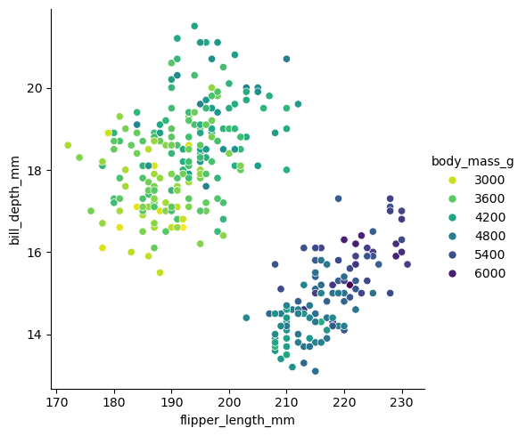

```python
sns.relplot(data=penguins, x="flipper_length_mm", y="bill_depth_mm", hue="body_mass_g",
           palette="viridis_r")

plt.show()
```

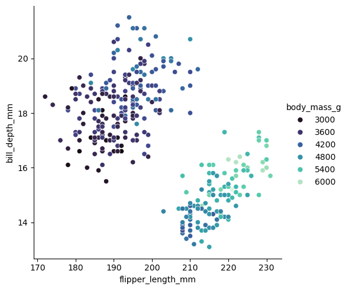

```python
sns.relplot(data=penguins, x="flipper_length_mm", y="bill_depth_mm", hue="body_mass_g",
           palette="mako")

plt.show()
```

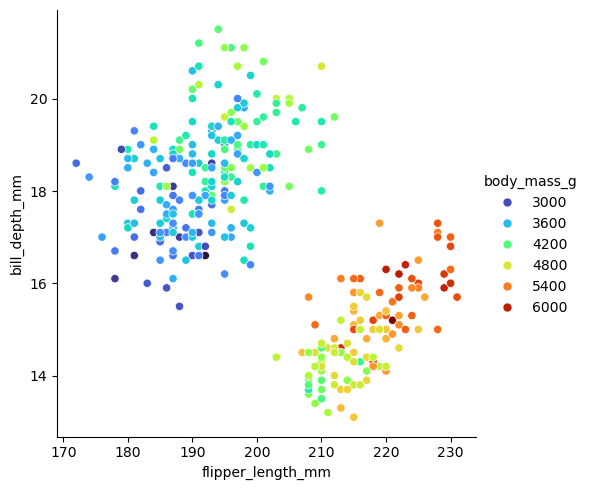

```python
sns.relplot(data=penguins, x="flipper_length_mm", y="bill_depth_mm", hue="body_mass_g",
           palette="turbo")

plt.show()
```

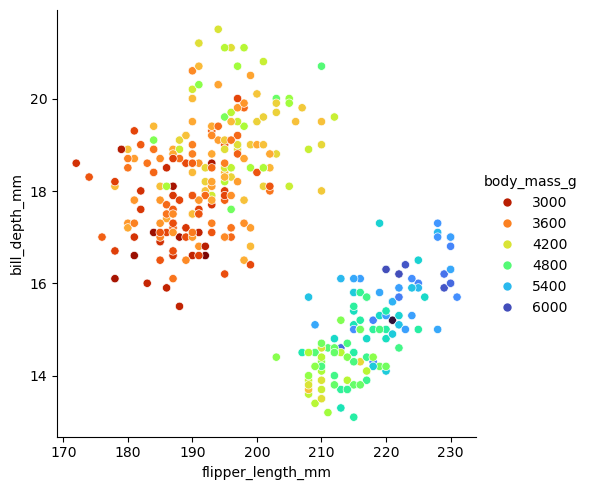

```python
sns.relplot(data=penguins, x="flipper_length_mm", y="bill_depth_mm", hue="body_mass_g",
           palette="turbo_r")

plt.show()
```

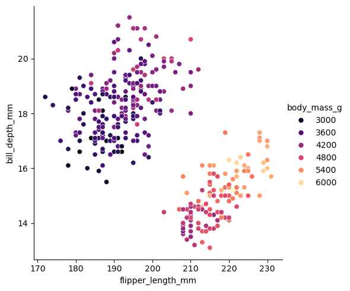

```python
sns.relplot(data=penguins, x="flipper_length_mm", y="bill_depth_mm", hue="body_mass_g",
           palette="magma")

plt.show()
```

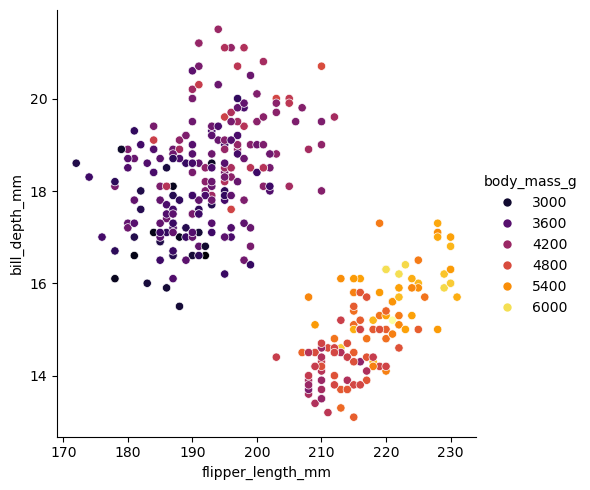

```python
sns.relplot(data=penguins, x="flipper_length_mm", y="bill_depth_mm", hue="body_mass_g",
           palette="inferno")

plt.show()
```

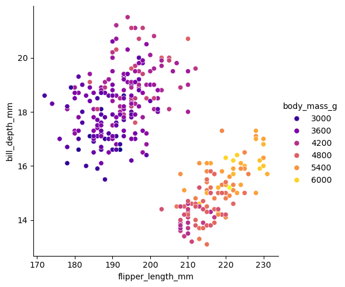

```python
sns.relplot(data=penguins, x="flipper_length_mm", y="bill_depth_mm", hue="body_mass_g",
           palette="plasma")

plt.show()
```

Sequential color palettes are good for distinguishing LOW to MEDIUM to HIGH values.

But, you can also distinguish being AWAY from the MID POINT!!! That's where DIVERGING color palettes are best!!!

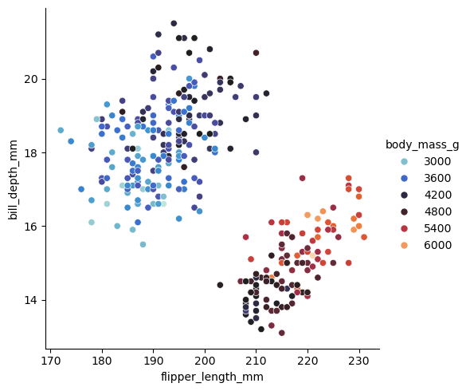

```python
sns.relplot(data=penguins, x="flipper_length_mm", y="bill_depth_mm", hue="body_mass_g",
           palette="icefire")

plt.show()
```

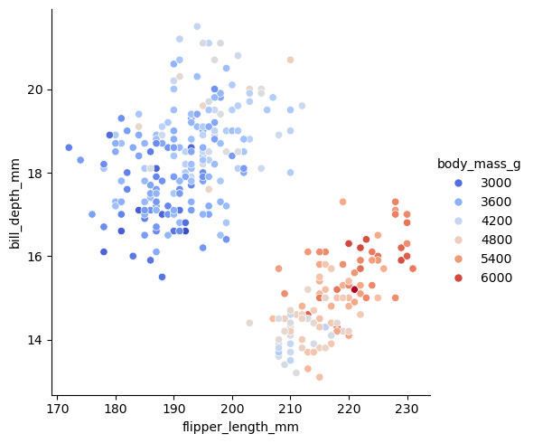

```python
sns.relplot(data=penguins, x="flipper_length_mm", y="bill_depth_mm", hue="body_mass_g",
           palette="coolwarm")

plt.show()
```

You can always include a cat variable as facets!!

You can use 4 vars, 3 can be numeric and 1 can be categorical.

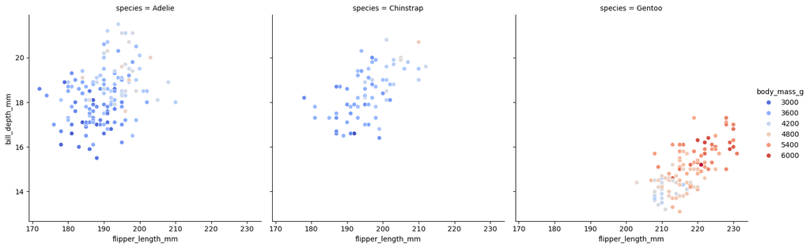

```python
sns.relplot(data=penguins, x="flipper_length_mm", y="bill_depth_mm", hue="body_mass_g", col="species",
           palette="coolwarm")

plt.show()
```

A second cat variable can be associated with row facets. This will give 5 variables.

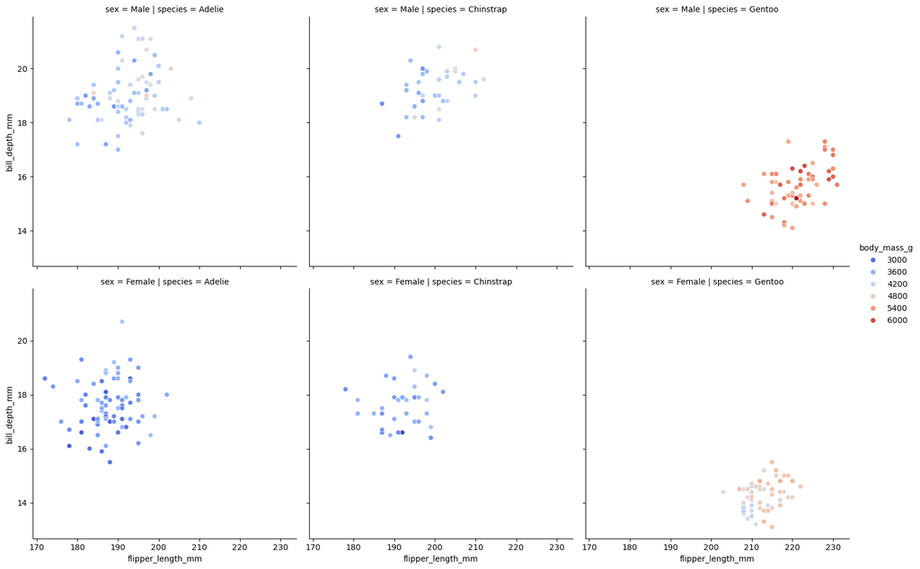

```python
sns.relplot(data=penguins, x="flipper_length_mm", y="bill_depth_mm", hue="body_mass_g", col="species", row="sex",
           palette="coolwarm")

plt.show()
```

We could even show 6 variables...if we include a 3rd cat variable as the marker shape.

Seaborn denotes the shape as the STYLE if we are associating the shape with a column in the DataFrame.

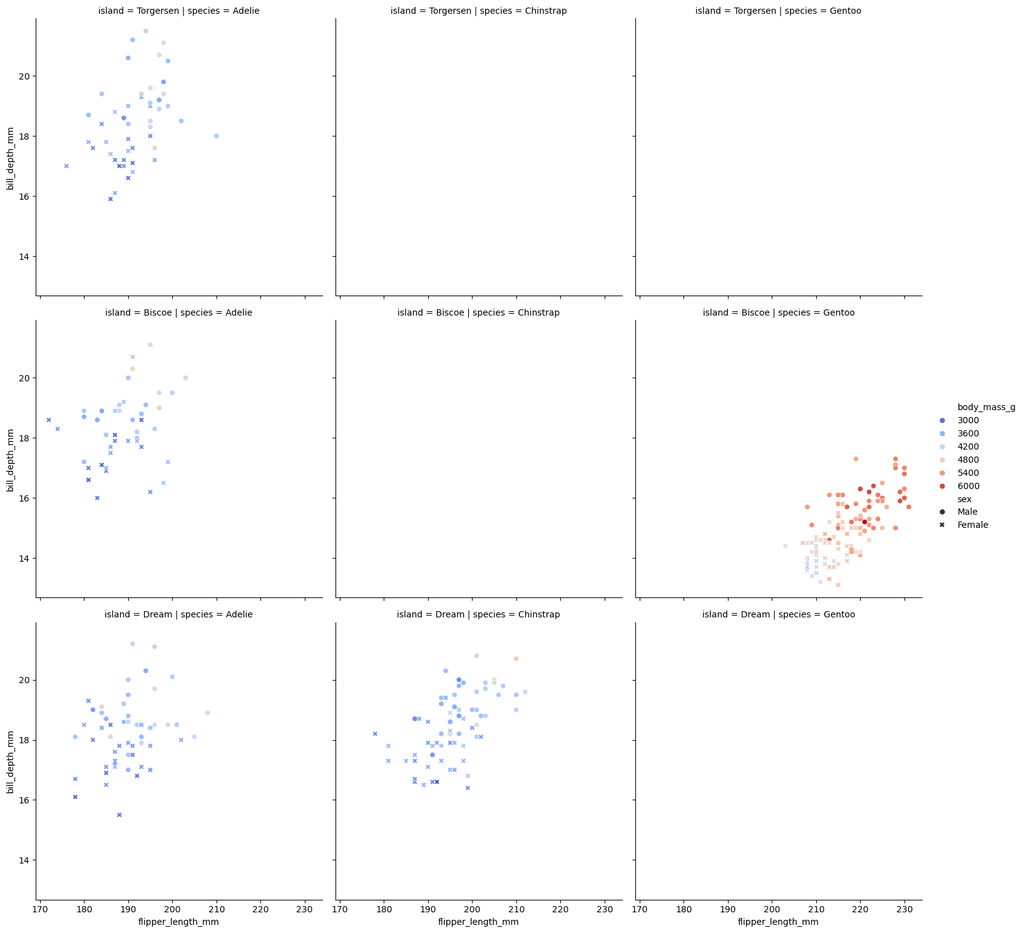

```python
sns.relplot(data=penguins, x="flipper_length_mm", y="bill_depth_mm", hue="body_mass_g", col="species", row="island",
            style="sex",
           palette="coolwarm")

plt.show()
```

## Background Theme or Style

By default the background is white without gridlines.

We can change the style using sns.set_style() function.

```python
sns.set_style("dark")
```

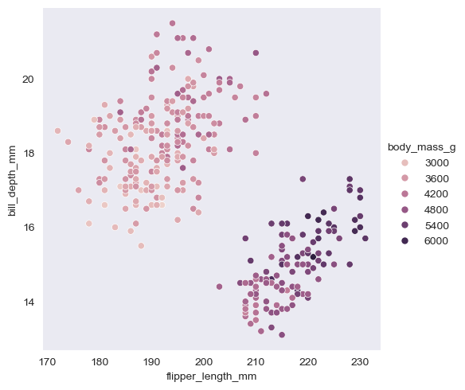

```python
sns.relplot(data=penguins, x="flipper_length_mm", y="bill_depth_mm", hue="body_mass_g")

plt.show()
```

```python
sns.set_style("whitegrid")
```

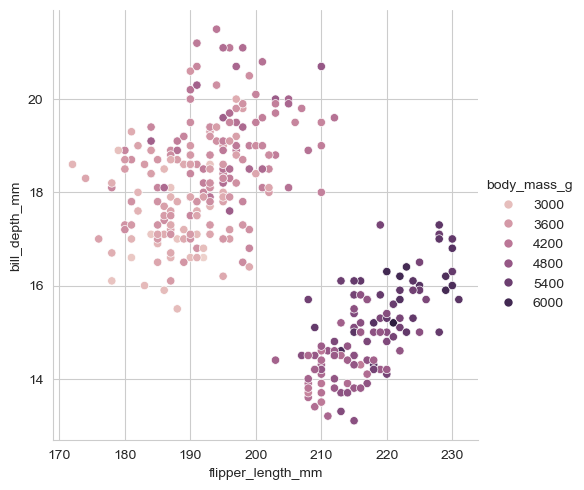

```python
sns.relplot(data=penguins, x="flipper_length_mm", y="bill_depth_mm", hue="body_mass_g")

plt.show()
```

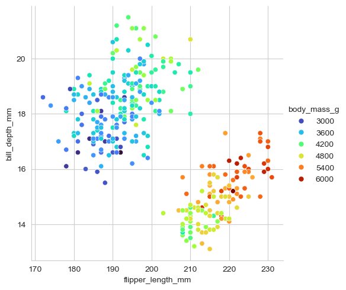

```python
sns.relplot(data=penguins, x="flipper_length_mm", y="bill_depth_mm", hue="body_mass_g", palette="turbo")

plt.show()
```

A DARK GRID has a grey background with WHITE grid lines.

```python
sns.set_style("darkgrid")
```

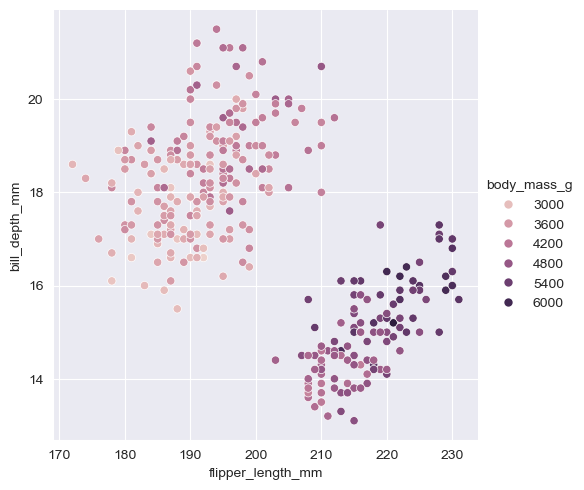

```python
sns.relplot(data=penguins, x="flipper_length_mm", y="bill_depth_mm", hue="body_mass_g")

plt.show()
```

If you want to use a BLACK background, you need to use a strange syntax.

```python
sns.set_style("darkgrid", {"axes.facecolor":".1"})
```

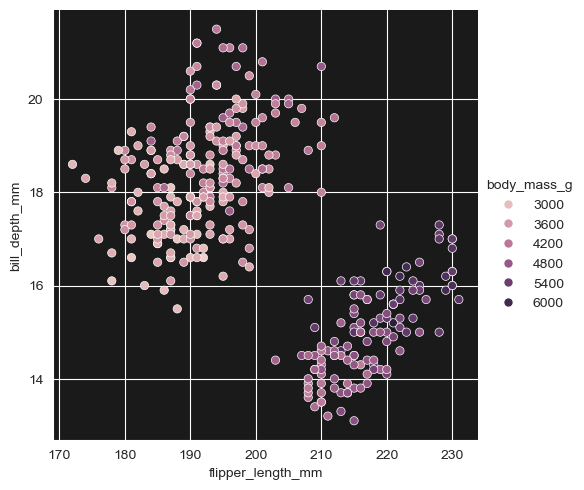

```python
sns.relplot(data=penguins, x="flipper_length_mm", y="bill_depth_mm", hue="body_mass_g")

plt.show()
```

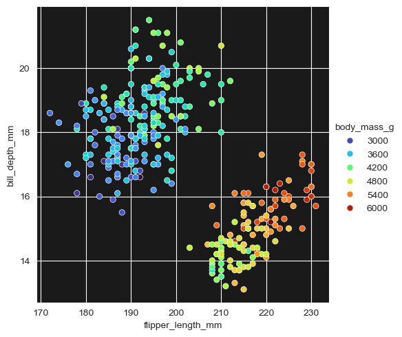

```python
sns.relplot(data=penguins, x="flipper_length_mm", y="bill_depth_mm", hue="body_mass_g", palette="turbo")

plt.show()
```

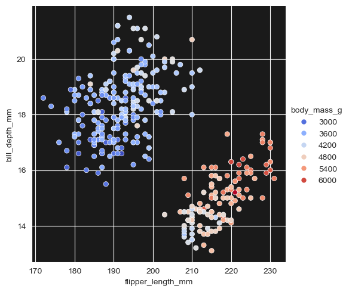

```python
sns.relplot(data=penguins, x="flipper_length_mm", y="bill_depth_mm", hue="body_mass_g", palette="coolwarm")

plt.show()
```

Background theme is applied to all facets!

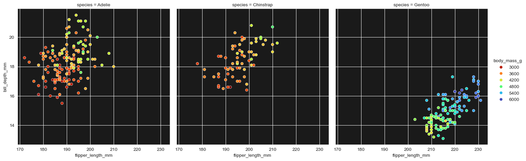

```python
sns.relplot(data=penguins, x="flipper_length_mm", y="bill_depth_mm", hue="body_mass_g", col="species", palette="turbo_r")

plt.show()
```

The default theme is the white background with no gridlines. Can get back to it by calling the "white" style.

```python
sns.set_style("white")
```

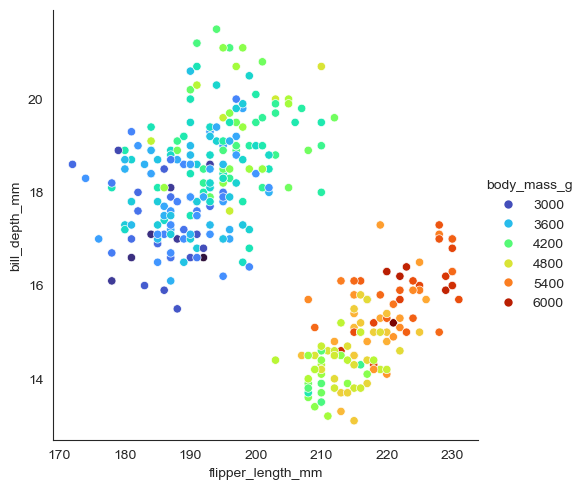

```python
sns.relplot(data=penguins, x="flipper_length_mm", y="bill_depth_mm", hue="body_mass_g", palette="turbo")

plt.show()
```